# Data Preprocessing

Indian Movie Face database (IMFDB) is a large unconstrained face database consisting of 34512 images of 100 Indian actors collected from more than 100 videos. All the images are manually selected and cropped from the video frames resulting in a high degree of variability interms of scale, pose, expression, illumination, age, resolution, occlusion, and makeup. IMFDB is the first face database that provides a detailed annotation of every image in terms of age, pose, gender, expression and type of occlusion that may help other face related applications.

# Data Attributes :

Selection of movies and actors: To ensure diversity in appearance of actors, movies are selected from 5 Indian languages namely, Hindi, Telugu, Kannada, Malayalam, and Bengali. For each actor, movies are selected such that they give wide variations in age. Selection of frames: Often, a single frame is selected from a shot (scene) unless there is a another frame with significant difference with the previously selected frame. If there are multiple variations available in a shot, face with occlusion and pose variation, were preferred. Small faces that are difficult to recognize manually are not considered. Cropping of faces: Faces are cropped with a tight bounding box. In order to maintain consistency across images, we followed a heuristic of cropping the face from forehead to chin.

Annotation: For every image, annotation is provided for following attributes: Expressions : Anger, Happiness, Sadness, Surprise, Fear, Disgust Illumination : Bad, Medium, High Pose : Frontal, Left, Right, Up, Down Occlusion : Glasses, Beard, Ornaments, Hair, Hand, None, Others Age : Child, Young, Middle and Old Makeup : Partial makeup, Over-makeup Gender : Male, Female

```python
import os, fnmatch

def findfiles (path, filter):
    for root, dirs, files in os.walk(path):
        for file in fnmatch.filter(files, filter):
            yield os.path.join(root, file)
```

# Read the Attributes from the Image Database

```python
import pandas as pd
columns=['FileName','Width','Height','MovieName','ActorName','Sex','Expression','Occluison','Illumination','Age','Pose','Makeup']
AllData=pd.DataFrame(columns=columns)

for textfile in findfiles(r'D:\\Deep Learning\Scaledgray', '*.txt'):
    try:
        filename = os.path.basename(textfile)
        #print filename
        #print textfile
        nj=pd.read_table(textfile, header=None)
        nj2=nj.ix[:,[0,3,4,5,7,8,9,10,11,12,13,14]]
        nj2.columns=columns
        nj1=nj2[(nj2.Height<2000) & (nj2.Width<2000)]
        AllData=AllData.append(nj1)
    except:
        simplyPutHere=1
        #print filename
```

# Check the Aspect Ratio :

```python
AllAspRat=(AllData.Height)/(AllData.Width)
import numpy as np
AspRat=np.asarray(AllAspRat)
```

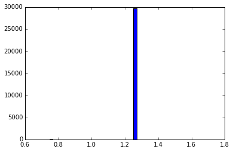

```python
import matplotlib.pyplot as plt
%pylab inline
plt.hist(AspRat,50)
#plt.xlim([1, 1.5])
plt.show()
```

# Converting the Colored Images to Gray Scale

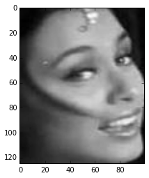

```python
import numpy as np
import matplotlib.pyplot as plt
import matplotlib.image as mpimg

def rgb2gray(rgb):
    return np.dot(rgb[...,:3], [0.299, 0.587, 0.144])

img = mpimg.imread('D:\Deep Learning\Scaledgray\Ranimukherji\KabhiKhushiKabhiGham\images\Ranimukherji_1_KabhiKhushiKabhiGham.jpg')
gray = rgb2gray(img)
plt.imshow(img, cmap = plt.get_cmap('gray'))
plt.show()
```

# Class Labels : Male = 0 and Female = 1

```python
def GenderAsssign(rowI):
    if rowI['Sex']=='MALE':
        return 0.0
    else:
        return 1.0
```

# Resizing the Image Vectors to 1 x 12500 ( 100 x 125)

```python
AllData['GenSig']=AllData.apply(GenderAsssign,axis=1)
JustRawImages=np.empty((0,12500), float32)
counterNew=0
GenderSignals=[]
for imfile in findfiles(r'D:\\Deep Learning\Scaledgray', '*.jpg'):
        filename = os.path.basename(imfile)
        img = mpimg.imread(imfile).reshape(1,12500).astype(np.float32)
        JustRawImages=vstack((JustRawImages,img[0]))
        GenderSignals.append(AllData.loc[AllData['FileName'] == filename].values[0][12])
        counterNew=counterNew+1
asarray(GenderSignals).astype(int64)
```

```python
asarray(GenderSignals).astype(int64)
```

[output not shown]

```python
np.savetxt('ImDa.out',JustRawImages)
```

```python
np.savetxt('GenD.out',asarray(GenderSignals).astype(int64))
```

```python
np.shape(JustRawImages)
```

```
(29425L, 12500L)
```

# Saving the Image Vectors and Class labels as Pickle File .

```python
import pickle
f = open('ImDa.pickle', 'wb')
pickle.dump(JustRawImages, f, pickle.HIGHEST_PROTOCOL)
f.close()
```

```python
import pickle
f = open('GenD.pickle', 'wb')
pickle.dump(GenderSignals, f, pickle.HIGHEST_PROTOCOL)
f.close()
```

```python
import pickle
k1=pickle.load( open( "ImDa.pickle", "rb" ) )
```

```python
type(k1)
```

```
numpy.ndarray
```

```python
np.shape(k1)
```

```python
import numpy as np
f = pickle.load(open('GenD.pickle', 'rb'))
```